# 1430_hands-on-part-1_FR

### Les cinq règles que respectent les niveaux 3 à 5

| Règle | Réglage | Pourquoi |
| --- | --- | --- |
| Des phrases entières, jusqu'à une taille limite | `TAILLE_MAX = 700` | Une phrase coupée peut être retrouvée, mais pas citée |
| Une phrase répétée entre les passages | `CHEVAUCHEMENT_PHRASES = 1` | La réponse est souvent à cheval sur une frontière |
| Les passages courts fusionnés avec le précédent | `TAILLE_MIN = 280` | Une ligne isolée n'a aucun contexte et ne répond à rien |
| Fil d'Ariane des titres complet dans le texte de recherche | — | « 2. Stratégie › 2.4 Axes prioritaires » sépare des sections aux formulations voisines |
| Tableaux tenus à part, lignes portant leur légende | `EXTRAIRE_TABLEAUX` | Un nombre ne veut rien dire sans les libellés de sa ligne et de sa colonne |

> 💡 **Mesuré, pas supposé.** Sur les deux rapports institutionnels ayant servi à régler ce notebook (66 et 81 pages, 12 questions dont les réponses sont connues) :

> | Niveau | Réponse dans le contexte | Bon passage en tête | |---|:-:|:-:| | 1 · Blocs fixes | 11/12 | 8/12 | | 2 · Fenêtres de phrases | 12/12 | **6/12** | | 3 · Passages structurels | 11/12 | 10/12 | | 4 · Deux granularités | **12/12** | **10/12** | | 5 · Deux granularités, tableaux et contexte | **12/12** | **10/12** |

> La leçon qui surprend le plus : **n'indexer que de petits morceaux est la pire option** (niveau 2). Une fenêtre de deux phrases contient rarement tous les mots d'une question, si bien que la recherche lexicale la perd. Les petits morceaux n'aident que lorsqu'un passage plus large se tient derrière eux — ce sont les niveaux 4 et 5.

> ⚠️ Ces chiffres proviennent de **deux** rapports et **douze** questions. Ils suffisent à départager des stratégies très différentes, pas à prouver qu'un niveau l'emporte sur un autre à une question près. Lancez le banc d'essai ci-dessous sur vos propres documents.

```python
sample = BIB.passages[:40]
tableau(pd.DataFrame([{"N°": p.id, "Document": p.doc[:30], "Section": (p.section or "—")[:36],
                          "Pages": ", ".join(map(str, p.pages)), "Nature": p.kind, "Caractères": len(p.text),
                          "Début": _html.escape(p.text[:80].replace(chr(10), " ")) + "…"} for p in sample]),
           title=f"✂️ {len(BIB.passages)} passages indexés",
           note=("Les 40 premiers sont affichés ; la liste complète est exportée dans passages.csv en partie D."
                 if len(BIB.passages) > 40 else None))
lengths = [len(p.text) for p in BIB.passages]
tableau(pd.DataFrame([{"Passages de contexte": len(BIB.passages), "Unités de recherche": len(BIB.units),
                          "Longueur moyenne d'un passage": int(np.mean(lengths)),
                          "Passages de tableau": sum(p.kind == "table" for p in BIB.passages),
                          "Stratégie": STRATEGIE_DECOUPAGE, "Sigles appris": len(SIGLES)}]),
           title="L'index en un coup d'œil")
```

✂️ 23 passages indexés

| N° | Document | Section | Pages | Nature | Caractères | Début |
| --- | --- | --- | --- | --- | --- | --- |
| 0 | Rapport annuel sur le marché d | — | 1 | text | 81 | DONNÉES FICTIVES — document de formation. Aucun chiffre de ce rapport n'est réel… |
| 1 | Rapport annuel sur le marché d | 1. Avant-propos | 1 | text | 297 | Ce rapport présente les principaux résultats de l'Enquête emploi continue (EEC) … |
| 2 | Rapport annuel sur le marché d | 2. Faits saillants | 1 | text | 278 | • Le taux de chômage annuel moyen s'établit à 7,9 % en 2025, contre 8,4 % en 20… |
| 3 | Rapport annuel sur le marché d | 3. Population en âge de travailler | 1, 2 | text | 388 | En 2025, la population en âge de travailler compte 11,2 millions de personnes. L… |
| 4 | Rapport annuel sur le marché d | 4. Activité et emploi | 2 | text | 159 | Le tableau 1 présente l'évolution trimestrielle des principaux indicateurs. Le t… |
| 5 | Rapport annuel sur le marché d | 4. Activité et emploi | 2 | table | 317 | Tableau 1 — Indicateurs trimestriels du marché du travail en 2025 (%) Taux d'act… |
| 6 | Rapport annuel sur le marché d | 4. Activité et emploi | 2 | text | 74 | Source : Institut national de la statistique, EEC 2025 (données fictives).… |
| 7 | Rapport annuel sur le marché d | 5. Chômage | 2 | text | 195 | Le chômage touche davantage les femmes (9,3 %) que les hommes (6,7 %). Il est pl… |
| 8 | Rapport annuel sur le marché d | 5. Chômage | 3 | table | 248 | Tableau 2 — Taux de chômage par région en 2025 (%) Littoral — Hommes: 8,1; Femme… |
| 9 | Rapport annuel sur le marché d | 5. Chômage | 3 | text | 120 | La durée moyenne de recherche d'emploi est de 14 mois. Un chômeur sur trois rech… |
| 10 | Rapport annuel sur le marché d | 6. Emploi informel | 3 | text | 263 | L'emploi informel désigne les emplois sans protection sociale ni contrat écrit. … |
| 11 | Rapport annuel sur le marché d | 7. Méthodologie | 3 | text | 524 | L'enquête repose sur un tirage aléatoire à deux degrés. Six cents zones de dénom… |
| 12 | Rapport annuel sur le marché d | 8. Diffusion et confidentialité | 4 | text | 271 | Les résultats trimestriels sont publiés 45 jours après la fin du trimestre de ré… |
| 13 | Rapport annuel sur le marché d | 9. Glossaire | 4 | text | 399 | Chômeur : personne de 15 ans ou plus, sans emploi, disponible pour travailler et… |
| 14 | Bulletin trimestriel de l'empl | — | 1 | text | 82 | DONNÉES FICTIVES — document de formation. Aucun chiffre de ce bulletin n'est rée… |
| 15 | Bulletin trimestriel de l'empl | Chômage | 1 | text | 250 | Au premier trimestre 2026, le taux de chômage s'établit à 7,4 % de la population… |
| 16 | Bulletin trimestriel de l'empl | Activité et emploi | 1 | text | 150 | Le taux d'activité est de 61,4 % et le taux d'emploi atteint 56,9 %. Le sous-emp… |
| 17 | Bulletin trimestriel de l'empl | Révisions et diffusion | 1 | text | 196 | Les estimations du quatrième trimestre 2025 publiées dans le rapport annuel sont… |
| 18 | Recensement de la population 2 | — | 1 | text | 82 | DONNÉES FICTIVES — document de formation. Aucun chiffre de ce document n'est rée… |
| 19 | Recensement de la population 2 | Effectifs | 1 | text | 244 | Au 15 mars 2024, date de référence du recensement, la population résidente du pa… |
| 20 | Recensement de la population 2 | Répartition territoriale | 1 | table | 336 | Tableau 1 — Population résidente par région en 2024 Littoral — Population: 5 112… |
| 21 | Recensement de la population 2 | Répartition territoriale | 1 | text | 85 | La part de la population résidant en milieu urbain atteint 47,3 % au niveau nati… |
| 22 | Recensement de la population 2 | Ménages | 2 | text | 172 | Le recensement dénombre 3 618 100 ménages ordinaires. La taille moyenne d'un mén… |

L'index en un coup d'œil

| Passages de contexte | Unités de recherche | Longueur moyenne d'un passage | Passages de tableau | Stratégie | Sigles appris |
| --- | --- | --- | --- | --- | --- |
| 23 | 59 | 226 | 3 | smart | 1 |

#### Le même document sous chaque niveau

```python
comparer_decoupage()
```

✂️ Les cinq niveaux sur « Rapport annuel sur le marché du travail… »

| Niveau | Passages | Unités de recherche | Longueur moyenne | Connaît sa section | Secondes | Premier passage |
| --- | --- | --- | --- | --- | --- | --- |
| 1 · Blocs fixes | 7 | 7 | 622 | — | 0.0 | Rapport annuel sur le marché du travail 2025 DONNÉES FICTIVES — document de formation. Aucun chiffre de ce rapport n'est réel. 1. Avant-propos Ce rapp… |
| 2 · Fenêtres de phrases | 36 | 36 | 142 | — | 0.0 | Avant-propos Ce rapport présente les principaux résultats de l'Enquête emploi continue (EEC) conduite en 2025 par l'Institut national de la statistiqu… |
| 3 · Passages structurels | 14 | 14 | 258 | ✅ | 0.0 | Ce rapport présente les principaux résultats de l'Enquête emploi continue (EEC) conduite en 2025 par l'Institut national de la statistique. Il couvre … |
| 4 · Deux granularités | 14 | 27 | 258 | ✅ | 0.0 | Ce rapport présente les principaux résultats de l'Enquête emploi continue (EEC) conduite en 2025 par l'Institut national de la statistique. Il couvre … |
| 5 · Deux granularités, tableaux et contexte | 14 | 37 | 258 | ✅ | 0.0 | Ce rapport présente les principaux résultats de l'Enquête emploi continue (EEC) conduite en 2025 par l'Institut national de la statistique. Il couvre … |

Les niveaux 1 et 2 ignorent les titres et les tableaux : un passage ne sait plus d'où il vient. Les niveaux 4 et 5 indexent une seconde granularité, plus fine — c'est pour cela qu'ils ont plus d'unités de recherche que de passages.

#### Choisir sur preuves, pas par conviction

`banc_essai()` réindexe votre collection avec chaque combinaison et la mesure. Il utilise, par ordre de préférence :

1. **vos propres questions**, si vous avez rempli `QUESTIONS_EVALUATION` dans les réglages — de loin les plus pertinentes :

   ```
   QUESTIONS_EVALUATION = [
       ("Combien de dimensions compte le modèle de maturité ?", ["12 dimensions"]),
       ("Quels pays ont participé au diagnostic ?", ["Tunisie", "Sénégal"]),
   ]
   ```

   Chaque entrée est une question et le texte qui doit figurer dans les passages transmis au modèle.
2. sinon des **questions-sondes construites à partir des documents eux-mêmes** : les mots d'une phrase doivent ramener une phrase *ultérieure* du même sujet. Un découpage qui coupe un sujet en deux échoue. C'est un indicateur indirect, pas un verdict.

L'indexation a lieu une fois par combinaison : cinq niveaux sur un rapport de 80 pages prennent donc environ une demi-minute — et bien davantage avec des embeddings neuronaux.

```python
# 🧪 À vous : écrivez les questions qui comptent pour vous. Voilà à quoi ressemble un vrai jeu d'évaluation.
if DOCUMENTS == ["exemple"] and not QUESTIONS_EVALUATION:
    QUESTIONS_EVALUATION = [
        ("Quel est le taux de chômage au deuxième trimestre ?", ["T2: 7,8"]),
        ("Quelle est la population de la région du Centre ?", ["4 870 500"]),
        ("Quelle est la part de l'emploi informel ?", ["71,5"]),
        ("Quelle est la taille moyenne d'un ménage ?", ["5,1 personnes"]),
        ("Les chercheurs peuvent-ils accéder aux microdonnées ?", ["centre d'accès sécurisé"]),
        ("Quand paraîtra le prochain bulletin de l'emploi ?", ["mi-août 2026"]),
        ("Quelle est la durée moyenne de recherche d'emploi ?", ["14 mois"]),
        ("Comment la non-réponse totale est-elle corrigée ?", ["repondération"]),
    ]

BANC_ESSAI = banc_essai(chunking=("fixed", "sentences", "sections", "hybrid", "smart"),
                      reranking=("smart",), show_questions=True)
```

Les 8 questions utilisées par le banc d'essai

| Question | Attendu dans le contexte |
| --- | --- |
| Quel est le taux de chômage au deuxième trimestre ? | T2: 7,8 |
| Quelle est la population de la région du Centre ? | 4 870 500 |
| Quelle est la part de l'emploi informel ? | 71,5 |
| Quelle est la taille moyenne d'un ménage ? | 5,1 personnes |
| Les chercheurs peuvent-ils accéder aux microdonnées ? | centre d'accès sécurisé |
| Quand paraîtra le prochain bulletin de l'emploi ? | mi-août 2026 |
| Quelle est la durée moyenne de recherche d'emploi ? | 14 mois |
| Comment la non-réponse totale est-elle corrigée ? | repondération |

```
  11 passages / 11 unités de recherche indexés en 0.2 s (Embeddings · paraphrase-multilingual-MiniLM-L12-v2) · 1 sigles et 187 mots appris · calibration du seuil…
  seuil 0.37 calibré en 1.3 s
  53 passages / 53 unités de recherche indexés en 0.5 s (Embeddings · paraphrase-multilingual-MiniLM-L12-v2) · 1 sigles et 183 mots appris · calibration du seuil…
  seuil 0.27 calibré en 1.2 s
  23 passages / 23 unités de recherche indexés en 0.4 s (Embeddings · paraphrase-multilingual-MiniLM-L12-v2) · 1 sigles et 175 mots appris · calibration du seuil…
  seuil 0.41 calibré en 1.3 s
  23 passages / 44 unités de recherche indexés en 1.0 s (Embeddings · paraphrase-multilingual-MiniLM-L12-v2) · 1 sigles et 175 mots appris · calibration du seuil…
  seuil 0.43 calibré en 1.2 s
  23 passages / 59 unités de recherche indexés en 0.0 s (Embeddings · paraphrase-multilingual-MiniLM-L12-v2) · 1 sigles et 175 mots appris · calibration du seuil…
  seuil 0.39 calibré en 0.6 s
  23 passages / 59 unités de recherche indexés en 0.0 s (Embeddings · paraphrase-multilingual-MiniLM-L12-v2) · 1 sigles et 175 mots appris · calibration du seuil…
  seuil 0.39 calibré en 0.5 s
```

🏁 Banc d'essai sur vos propres documents

| Découpage | Reclassement | Passages | Unités | Réponse dans le contexte | Bon passage en tête | Indexation (s) | Par question (ms) | Meilleur |
| --- | --- | --- | --- | --- | --- | --- | --- | --- |
| 1 · Blocs fixes | 2 · Couverture, densité et type de réponse | 11 | 11 | 8/8 | 8/8 | 1.5 | 61 | 🏆 |
| 2 · Fenêtres de phrases | 2 · Couverture, densité et type de réponse | 53 | 53 | 8/8 | 7/8 | 1.7 | 58 |  |
| 3 · Passages structurels | 2 · Couverture, densité et type de réponse | 23 | 23 | 8/8 | 8/8 | 1.6 | 63 | 🏆 |
| 4 · Deux granularités | 2 · Couverture, densité et type de réponse | 23 | 44 | 8/8 | 8/8 | 2.2 | 47 | 🏆 |
| 5 · Deux granularités, tableaux et contexte | 2 · Couverture, densité et type de réponse | 23 | 59 | 8/8 | 8/8 | 0.6 | 25 | 🏆 |

Mesuré sur cette collection uniquement : relancez-le sur la vôtre avant de vous fier à un classement. Une combinaison qui gagne d'une seule question fait match nul, elle ne gagne pas.

Parcours approfondi

B4 · La chaîne de recherche

Treize étapes entre la question et la réponse — et les quatre niveaux de reclassement.

### Les treize étapes, et là où vous pouvez agir

| # | Étape | Ce qu'elle fait | Réglage |
| --- | --- | --- | --- |
| 1 | **Question** | telle que saisie par l'utilisateur | — |
| 2 | **Question de suivi** | « Et pour les hommes ? » est réécrite en question autonome (B7) | `MEMOIRE_PAR_MODELE` |
| 3 | **Orthographe** | un mot que les documents n'emploient jamais est remplacé par le plus proche qu'ils emploient : *régon* → *région* | — |
| 4 | **Normalisation** | minuscules, accents, racines des mots ; les mots interrogatifs (« nombre de », « liste », « signifie ») sont écartés | `MOTS_VIDES` |
| 5 | **Expansion** | glossaire métier, plus les sigles appris des documents | `GLOSSAIRE` |
| 6 | **BM25** | mots exacts, sur chaque unité de recherche | `STRATEGIE_DECOUPAGE` |
| 7 | **Sémantique** | le sens plutôt que les mots | `UTILISER_EMBEDDINGS` |
| 8 | **Fusion** | les deux classements fusionnés (Reciprocal Rank Fusion) | — |
| 9 | **Reclassement** | l'ordre se décide ici | `RECLASSEMENT` |
| 10 | **Fenêtres → passages** | chaque petite unité restitue le passage qu'un humain devrait lire | `STRATEGIE_DECOUPAGE` |
| 11 | **Garde-fous** | seuil, contrôle de l'année, refus (B5) | `SEUIL_MANUEL` |
| 12 | **Réponse** | rédigée par le modèle, ou extraite du passage | Groq / Ollama |
| 13 | **Contrôles** | chiffres vérifiés, termes introuvables, meilleure réponse écartée par un filtre (B9) | — |

L'étape 7 mérite un mot : **sans `sentence-transformers`, le notebook se rabat sur une approximation hors ligne (LSA sur n-grammes de caractères)**, qui rapproche des orthographes plutôt que des sens. Elle ne tombe jamais en panne, mais elle ne peut pas relier « participer à l'évaluation » et « la Banque a mené des missions de diagnostic en ». Si vos questions emploient les mots de vos utilisateurs plutôt que ceux du rapport, installez le modèle neuronal — `INSTALLER_EMBEDDINGS = True`.

### Les quatre niveaux de reclassement

Le classement fusionné est rarement le bon ordre. Le reclassement réévalue la liste courte ; `RECLASSEMENT` choisit comment.

| `RECLASSEMENT` | Ce qu'il fait | Coût |
| --- | --- | --- |
| `"none"` | **0 · Aucun.** Conserve l'ordre de la fusion. | Gratuit |
| `"coverage"` | **1 · Couverture de la question.** Part des termes pondérés de la question présents dans le passage. Un mot rare pèse plus qu'un mot fréquent ; un mot absent de toute la collection pèse le plus, et c'… | Gratuit |
| `"smart"` | **2 · Couverture, densité et type de réponse.** Sur un long rapport, beaucoup de passages couvrent toute la question : les scores égaux sont alors départagés par **ce que demande la question** — une q… | Gratuit |
| `"cross-encoder"` | **3 · Cross-encoder neuronal.** Un modèle lit la question et le passage *ensemble* et note la paire. Le plus précis, et le plus lent : il exige `sentence-transformers` et quelques centaines de millise… | ~0,3–1 s/question |

> 💡 **Mesuré sur les deux mêmes rapports**, découpage fixé au niveau 5 :

> | Reclassement | Réponse dans le contexte | Bon passage en tête | |---|:-:|:-:| | 0 · Aucun | 10/12 | 6/12 | | 1 · Couverture de la question | 12/12 | 8/12 | | 2 · Couverture, densité et type de réponse | **12/12** | **10/12** |

> Le cross-encoder manque volontairement à ce tableau : il n'a pas pu être téléchargé dans l'environnement où le notebook a été réglé. Lancez vous-même `banc_essai(reranking=("smart", "cross-encoder"))` — sur les bancs d'essai publics, un cross-encoder l'emporte généralement, au prix de la latence.

> 💡 **Le glossaire vous appartient.** Enrichissez `GLOSSAIRE` (cellule T4) du vocabulaire de vos utilisateurs — « cadre » → « diagnostic du modèle de maturité » sur le guide de la BAD, par exemple. C'est souvent l'amélioration la plus rentable de toutes, et c'est la bonne réponse quand une question échoue systématiquement parce que vos utilisateurs et vos rapports emploient des mots différents.

```python
q = ("Quel était le taux de chômage au quatrième trimestre 2025 ?" if DOCUMENTS == ["exemple"]
     else f"Que dit le document à propos de : {next((e.text for d in BIB.documents for e in d.elements if e.type == 'heading' and e.level > 1), 'le sujet principal')} ?")
tableau(pd.DataFrame([{"Question": q, "Termes analysés": ", ".join(analyser(q)),
                          "Ajouts du glossaire": "<br>".join(f"<b>{k}</b> → {t}" for k, t in enrichir_question(q)[1]) or "—"}]),
           title="Ce que le moteur de recherche « voit » dans une question")

def _ranking(docs):
    return [f"{p.doc[:28]}… › {p.section[:22]} ({s:.2f})" for p, s in BIB.rechercher(q, 4, docs)]
columns = {"Tous les documents": _ranking(None)}
for d in BIB.documents[:2]:
    columns[f"Seulement : {d.short[:30]}"] = _ranking([d.id])
length = max(len(v) for v in columns.values())
tableau(pd.DataFrame({"Rang": range(1, length + 1),
                         **{k: v + ["—"] * (length - len(v)) for k, v in columns.items()}}),
           title=f"Effet du filtre par document · « {q} »",
           note=f"Recherche sémantique : {BIB.semantic.name}. Entre parenthèses : la confiance.")
```

Ce que le moteur de recherche « voit » dans une question

| Question | Termes analysés | Ajouts du glossaire |
| --- | --- | --- |
| Quel était le taux de chômage au quatrième trimestre 2025 ? | taux, chom, quatriem, trimestr, 2025 | **quatrieme trimestre** → t4 |

Effet du filtre par document · « Quel était le taux de chômage au quatrième trimestre 2025 ? »

| Rang | Tous les documents | Seulement : Rapport annuel sur le marché d | Seulement : Bulletin trimestriel de l'empl |
| --- | --- | --- | --- |
| 1 | Bulletin trimestriel de l'em… › Chômage (1.00) | Rapport annuel sur le marché… › 4. Activité et emploi (1.00) | Bulletin trimestriel de l'em… › Chômage (1.00) |
| 2 | Rapport annuel sur le marché… › 4. Activité et emploi (1.00) | Rapport annuel sur le marché… › 4. Activité et emploi (0.84) | Bulletin trimestriel de l'em… › Révisions et diffusion (0.69) |
| 3 | Rapport annuel sur le marché… › 4. Activité et emploi (0.84) | Rapport annuel sur le marché… › 5. Chômage (0.44) | Bulletin trimestriel de l'em… › Activité et emploi (0.36) |
| 4 | Bulletin trimestriel de l'em… › Révisions et diffusion (0.69) | Rapport annuel sur le marché… › 5. Chômage (0.44) | Bulletin trimestriel de l'em… › (0.22) |

Recherche sémantique : Embeddings · paraphrase-multilingual-MiniLM-L12-v2. Entre parenthèses : la confiance.

#### Voir la chaîne, puis y suivre une question

`afficher_chaine()` dessine la chaîne telle qu'elle est configurée en ce moment. `expliquer("…")` fait passer une question par chaque étape et montre ce que chacune a changé — le moyen le plus rapide de comprendre *pourquoi* une réponse est ce qu'elle est.

```python
afficher_chaine()

# 🧪 À vous : mettez ici une de vos questions — idéalement une qui vous a déçu.
_ = expliquer(questions_suggerees()[0])
```

🔗 La chaîne RAG, telle que configurée en ce moment

ÉTAPE 1

Question

saisie par l'utilisateur

ÉTAPE 2

Relance

réécrite en question autonome

ÉTAPE 3

Orthographe

les mots absents des documents sont corrigés

ÉTAPE 4

Normalisation

minuscules, accents, racines, mots interrogatifs retirés

ÉTAPE 5

Enrichissement

glossaire + sigles appris dans les documents

ÉTAPE 6

BM25

mots exacts, sur chaque unité de recherche

59 unités

ÉTAPE 7

Sémantique

sens, sur chaque unité de recherche

Embeddings · paraphrase-multilingual-MiniLM-L12-v2

ÉTAPE 8

Fusion

les deux classements fusionnés (RRF)

ÉTAPE 9

Reclassement

ordre décidé par le niveau que vous avez choisi

2 · Couverture, densité et type de réponse

ÉTAPE 10

Fenêtres → passages

chaque unité redonne le passage à lire

ÉTAPE 11

Garde-fous

seuil, contrôle des années, refus

seuil 0.39

ÉTAPE 12

Réponse

rédigée par le modèle, ou extraite

mode extractif

ÉTAPE 13

Vérifications

chiffres, termes manquants, filtre

Découpage : **5 · Deux granularités, tableaux et contexte** · Reclassement : **2 · Couverture, densité et type de réponse** · Passages remis à la réponse : **4**

🔍 Quel est le taux de chômage des femmes dans la région du Littoral ?

| Type de question | **other** — aucun traitement particulier |
| --- | --- |
| 4 · Termes retenus | taux (0.9), chom (1.1), femm (1.5), region (2.0), littoral (2.6) |
| 5 · Enrichissement | rien à ajouter |
| 6 · BM25 (mots exacts) | 1. **5. Chômage** · p. 3 (7.44) 2. **5. Chômage** · p. 3 (7.14) 3. **5. Chômage** · p. 2 (6.28) 4. **5. Chômage** · p. 3 (6.25) |
| 7 · Embeddings · paraphrase-multilingual-MiniLM-L12-v2 | 1. **5. Chômage** · p. 2 (0.76) 2. **5. Chômage** · p. 2 (0.74) 3. **5. Chômage** · p. 3 (0.72) 4. **5. Chômage** · p. 3 (0.71) |
| 8 · Fusion | 1. **5. Chômage** · p. 3 (0.03) 2. **5. Chômage** · p. 2 (0.03) 3. **5. Chômage** · p. 2 (0.03) 4. **5. Chômage** · p. 3 (0.03) |
| 9 · Reclassement · 2 · Couverture, densité et type de réponse | 1. **5. Chômage** · p. 3 (couverture 1.00) 2. **5. Chômage** · p. 2 (couverture 0.68) 3. **5. Chômage** · p. 2 (couverture 0.68) 4. **5. Chômage** · p. 3 (couverture 0.49) |
| 10 · Passages retournés | 1. Rapport annuel sur le marché du travail… · 5. Chômage · p. 3 2. Rapport annuel sur le marché du travail… · 5. Chômage · p. 2 3. Bulletin trimestriel de l'emploi T1 2026 · Chômage · p. 1 4. Rapport … |
| 11 · Garde-fous | confiance **1.00** face au seuil **0.39** → **réponse** |

❓ Quel est le taux de chômage des femmes dans la région du Littoral ?

RÉPONSEconfiance 1.00extractivechiffres vérifiés 8/811:41:07 · 0.03 s

Tableau 2 — Taux de chômage par région en 2025 (%): Littoral — Hommes: 8,1; Femmes: 11,2; Ensemble: 9,6. Centre — Hommes: 6,4; Femmes: 8,9; Ensemble: 7,6. <sup>1</sup>

**Sources (4)**

page 3

**[1]** Rapport annuel sur le marché du travail…**5. Chômage** · p. 3 · table · confiance 1.00  
“Tableau 2 — Taux de chômage par région en 2025 (%) Littoral — Hommes: 8,1; Femmes: 11,2; Ensemble: 9,6. Centre — Hommes: 6,4; Femmes: 8,9; Ensemble: 7,6. Nord — Hommes: 5,9; Femmes: 8,0; Ensemble: 6,9. Sud — Hommes: 6,2;…”

page 2

**[2]** Rapport annuel sur le marché du travail…**5. Chômage** · p. 2 · text · confiance 0.68  
“Le chômage touche davantage les femmes (9,3 %) que les hommes (6,7 %). Il est plus élevé en milieu urbain (10,4 %) qu'en milieu rural (5,2 %). Le tableau 2 détaille le taux de chômage par région.…”

**[3]** Bulletin trimestriel de l'emploi T1 2026**Chômage** · p. 1 · text · confiance 0.44  
“Au premier trimestre 2026, le taux de chômage s'établit à 7,4 % de la population active, en baisse de 0,2 point par rapport au quatrième trimestre 2025. Il atteint 16,9 % chez les jeunes de 15 à 24 ans, 8,8 % chez les fe…”

**[4]** Rapport annuel sur le marché du travail…**7. Méthodologie** · p. 3 · text · confiance 0.36  
“L'enquête repose sur un tirage aléatoire à deux degrés. Six cents zones de dénombrement sont sélectionnées avec une probabilité proportionnelle à leur taille, puis vingt logements sont tirés dans chaque zone, soit 12 000…”

Parcours approfondi

B5 · Garde-fous et calibration du seuil

Ne répondre que lorsque les documents le permettent.

Trois garde-fous décident si l'assistant peut répondre :

1. **Seuil de confiance** : si le meilleur passage n'est pas assez pertinent, l'assistant refuse **sans appeler le modèle** ;
2. **Contrôle de l'année** : une année mentionnée dans la question doit figurer dans les passages ;
3. **Consigne stricte** : répondre uniquement à partir des sources, les citer, et refuser avec une phrase fixe sinon.

### Comment le seuil est calculé

**Confiance d'une question** = poids des mots de la question retrouvés dans le meilleur passage ÷ poids de tous les mots de la question. Les mots rares pèsent plus ; les mots retrouvés **nulle part** dans les documents (comme « hôpitaux ») pèsent le plus, car ils signalent une question hors sujet.

**Calibration** : le notebook pose deux séries de questions de référence — des questions construites à partir des **titres de section** (la réponse existe) et des questions **hors sujet** (aucune réponse). Le seuil est fixé juste au-dessus du meilleur score hors sujet :

> **Seuil = meilleure confiance hors sujet + 0,05** (plafonné à 0,95)

> ⚠️ Ce seuil est un point de départ : ajustez-le dans les interfaces si l'assistant refuse trop souvent, ou pas assez. Pour le fixer vous-même : `SEUIL_MANUEL = 0.5`.

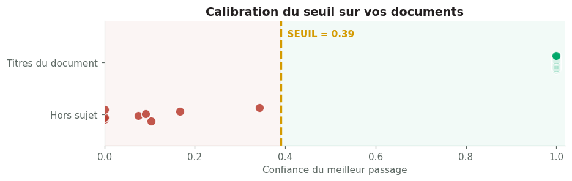

Questions de référence

| Question | Réponse existe | Confiance |
| --- | --- | --- |
| Que dit le document sur : Avant-propos ? | True | 1.000 |
| Que dit le document sur : Faits saillants ? | True | 1.000 |
| Que dit le document sur : Population en âge de travailler ? | True | 1.000 |
| Que dit le document sur : Activité et emploi ? | True | 1.000 |
| Que dit le document sur : Chômage ? | True | 1.000 |
| Que dit le document sur : Emploi informel ? | True | 1.000 |
| Que dit le document sur : Méthodologie ? | True | 1.000 |
| Que dit le document sur : Diffusion et confidentialité ? | True | 1.000 |
| Que dit le document sur : Glossaire ? | True | 1.000 |
| Que dit le document sur : Révisions et diffusion ? | True | 1.000 |
| Que dit le document sur : Effectifs ? | True | 1.000 |
| Que dit le document sur : Répartition territoriale ? | True | 1.000 |
| Que dit le document sur : Ménages ? | True | 1.000 |
| Combien d'hôpitaux compte la région du Nord ? | False | 0.343 |
| Quelle est la production nationale de cacao ? | False | 0.167 |
| Quelle équipe a gagné la dernière coupe du monde de football ? | False | 0.103 |
| Combien de vaccins ont été administrés contre la rougeole ? | False | 0.091 |
| Quel est le prix du maïs au kilogramme sur les marchés ? | False | 0.075 |
| Quelle est la recette traditionnelle du couscous ? | False | 0.000 |
| Quel temps fera-t-il demain dans la capitale ? | False | 0.000 |
| Qui est l'auteur du roman le plus vendu cette année ? | False | 0.000 |

❓ Quel est le prix du maïs au kilogramme ?

REFUSconfiance 0.00guardrail11:41:08 · 0.03 s

Information non disponible dans les documents.

Motif : confiance 0.00 inférieure au seuil 0.39

**Sources (4)**

**[1]** Recensement de la population 2024**Ménages** · p. 2 · text · confiance 0.00  
“Le recensement dénombre 3 618 100 ménages ordinaires. La taille moyenne d'un ménage est de 5,1 personnes, contre 5,4 en 2013. Un ménage sur quatre est dirigé par une femme.…”

**[2]** Rapport annuel sur le marché du travail…**7. Méthodologie** · p. 3 · text · confiance 0.00  
“L'enquête repose sur un tirage aléatoire à deux degrés. Six cents zones de dénombrement sont sélectionnées avec une probabilité proportionnelle à leur taille, puis vingt logements sont tirés dans chaque zone, soit 12 000…”

**[3]** Bulletin trimestriel de l'emploi T1 2026**Chômage** · p. 1 · text · confiance 0.00  
“Au premier trimestre 2026, le taux de chômage s'établit à 7,4 % de la population active, en baisse de 0,2 point par rapport au quatrième trimestre 2025. Il atteint 16,9 % chez les jeunes de 15 à 24 ans, 8,8 % chez les fe…”

**[4]** Rapport annuel sur le marché du travail…**2. Faits saillants** · p. 1 · text · confiance 0.00  
“• Le taux de chômage annuel moyen s'établit à 7,9 % en 2025, contre 8,4 % en 2024. • Le taux d'activité atteint 61,2 % en moyenne annuelle. • La part de l'emploi informel dans l'emploi total est estimée à 71,5 %. • Le ch…”

❓ Quel sera le taux de chômage en 2030 ?

REFUSconfiance 0.27guardrail11:41:08 · 0.02 s

Information non disponible dans les documents.

Motif : confiance 0.27 inférieure au seuil 0.39

**Sources (4)**

**[1]** Rapport annuel sur le marché du travail…**5. Chômage** · p. 3 · table · confiance 0.27  
“Tableau 2 — Taux de chômage par région en 2025 (%) Littoral — Hommes: 8,1; Femmes: 11,2; Ensemble: 9,6. Centre — Hommes: 6,4; Femmes: 8,9; Ensemble: 7,6. Nord — Hommes: 5,9; Femmes: 8,0; Ensemble: 6,9. Sud — Hommes: 6,2;…”

**[2]** Rapport annuel sur le marché du travail…**5. Chômage** · p. 2 · text · confiance 0.27  
“Le chômage touche davantage les femmes (9,3 %) que les hommes (6,7 %). Il est plus élevé en milieu urbain (10,4 %) qu'en milieu rural (5,2 %). Le tableau 2 détaille le taux de chômage par région.…”

**[3]** Rapport annuel sur le marché du travail…**4. Activité et emploi** · p. 2 · table · confiance 0.27  
“Tableau 1 — Indicateurs trimestriels du marché du travail en 2025 (%) Taux d'activité — T1: 60,9; T2: 61,5; T3: 61,1; T4: 61,3. Taux d'emploi — T1: 55,8; T2: 56,7; T3: 56,4; T4: 56,7. Taux de chômage — T1: 8,3; T2: 7,8; …”

**[4]** Bulletin trimestriel de l'emploi T1 2026**Chômage** · p. 1 · text · confiance 0.27  
“Au premier trimestre 2026, le taux de chômage s'établit à 7,4 % de la population active, en baisse de 0,2 point par rapport au quatrième trimestre 2025. Il atteint 16,9 % chez les jeunes de 15 à 24 ans, 8,8 % chez les fe…”

```python
cal = BIB.calibration
fig, ax = plt.subplots(figsize=(8.6, 2.8))
for rank, (exists, colour) in enumerate([(False, C["brick"]), (True, C["green"])]):
    v = cal.loc[cal["Réponse existe"] == exists, "Confiance"]
    ax.scatter(v, np.full(len(v), rank) + np.linspace(-0.13, 0.13, len(v)), s=95, color=colour,
               alpha=0.85, edgecolor="white", linewidth=1.2, zorder=3)
ax.axvline(BIB.threshold, color=C["ochre"], linewidth=2.2, linestyle="--")
ax.axvspan(0, BIB.threshold, color=C["brick"], alpha=0.05); ax.axvspan(BIB.threshold, 1.02, color=C["green"], alpha=0.05)
ax.text(BIB.threshold, 1.55, f"  SEUIL = {BIB.threshold:.2f}", color=C["ochre"], fontweight="bold", va="center")
ax.set_yticks([0, 1], ["Hors sujet", "Titres du document"]); ax.set_xlim(0, 1.02); ax.set_ylim(-0.6, 1.8)
ax.set_xlabel("Confiance du meilleur passage"); ax.set_title("Calibration du seuil sur vos documents")
plt.tight_layout(); fig.savefig(DOSSIER_SORTIE / "calibration_seuil.png", dpi=160); plt.show()
tableau(cal.sort_values("Confiance", ascending=False), title="Questions de référence")

for q in ["Quel est le prix du maïs au kilogramme ?", "Quel sera le taux de chômage en 2030 ?"]:
    BIB.afficher(BIB.repondre(q))
```

Parcours approfondi

B6 · Interroger plusieurs documents

Des réponses qui combinent plusieurs rapports, avec la source de chaque chiffre.

Avec plusieurs documents, deux situations se présentent :

- **la question vise un document précis** : le filtre de documents empêche qu'un rapport voisin au vocabulaire proche ne s'y glisse ;
- **la question compare** des périodes ou des documents (« évolution », « entre », « par rapport à ») : l'assistant rassemble des passages issus de **plusieurs documents** et donne **chaque valeur avec sa source**.

> ⚠️ **Le piège des documents jumeaux.** Deux bulletins trimestriels rédigés de la même façon ne diffèrent que par leur période. Sans en-tête contextuel, l'assistant peut citer le mauvais trimestre en toute confiance.

❓ Comment le taux de chômage a-t-il évolué entre le quatrième trimestre 2025 et le premier trimestre 2026 ?

RÉPONSEconfiance 1.00extractivechiffres vérifiés 16/1611:41:08 · 0.03 s

Au premier trimestre 2026, le taux de chômage s'établit à 7,4 % de la population active, en baisse de 0,2 point par rapport au quatrième trimestre 2025. <sup>1</sup> — Rapport annuel sur le marché du travail…: Tableau 1 — Indicateurs trimestriels du marché du travail en 2025 (%): Taux de chômage — T1: 8,3; T2: 7,8; T3: 7,7; T4: 7,6. Sous-emploi lié à la durée du travail — T1: 12,9; T2: 12,4; T3: 12,2; T4: 12,0. <sup>3</sup>

**Sources (4)**

page 1

**[1]** Bulletin trimestriel de l'emploi T1 2026**Chômage** · p. 1 · text · confiance 1.00  
“Au premier trimestre 2026, le taux de chômage s'établit à 7,4 % de la population active, en baisse de 0,2 point par rapport au quatrième trimestre 2025. Il atteint 16,9 % chez les jeunes de 15 à 24 ans, 8,8 % chez les fe…”

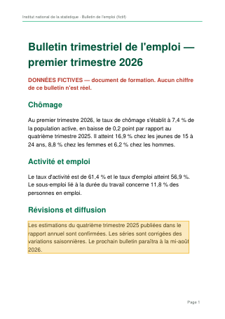

page 1

**[2]** Bulletin trimestriel de l'emploi T1 2026**Révisions et diffusion** · p. 1 · text · confiance 0.55  
“Les estimations du quatrième trimestre 2025 publiées dans le rapport annuel sont confirmées. Les séries sont corrigées des variations saisonnières. Le prochain bulletin paraîtra à la mi-août 2026.…”

**[3]** Rapport annuel sur le marché du travail…**4. Activité et emploi** · p. 2 · table · confiance 0.54  
“Tableau 1 — Indicateurs trimestriels du marché du travail en 2025 (%) Taux d'activité — T1: 60,9; T2: 61,5; T3: 61,1; T4: 61,3. Taux d'emploi — T1: 55,8; T2: 56,7; T3: 56,4; T4: 56,7. Taux de chômage — T1: 8,3; T2: 7,8; …”

**[4]** Rapport annuel sur le marché du travail…**4. Activité et emploi** · p. 2 · text · confiance 0.48  
“Le tableau 1 présente l'évolution trimestrielle des principaux indicateurs. Le taux d'emploi progresse de 0,9 point entre le premier et le quatrième trimestre.…”

❓ Quel est le taux de chômage des jeunes ?

RÉPONSEconfiance 1.00extractivechiffres vérifiés 3/311:41:08 · 0.03 s

• Le chômage des jeunes de 15 à 24 ans reste élevé, à 17,6 %. <sup>2</sup>

**Sources (4)**

page 1

**[1]** Bulletin trimestriel de l'emploi T1 2026**Chômage** · p. 1 · text · confiance 1.00  
“Au premier trimestre 2026, le taux de chômage s'établit à 7,4 % de la population active, en baisse de 0,2 point par rapport au quatrième trimestre 2025. Il atteint 16,9 % chez les jeunes de 15 à 24 ans, 8,8 % chez les fe…”

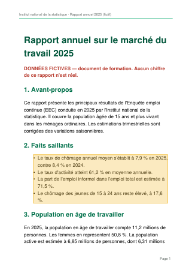

page 1

**[2]** Rapport annuel sur le marché du travail…**2. Faits saillants** · p. 1 · text · confiance 1.00  
“• Le taux de chômage annuel moyen s'établit à 7,9 % en 2025, contre 8,4 % en 2024. • Le taux d'activité atteint 61,2 % en moyenne annuelle. • La part de l'emploi informel dans l'emploi total est estimée à 71,5 %. • Le ch…”

**[3]** Rapport annuel sur le marché du travail…**9. Glossaire** · p. 4 · text · confiance 1.00  
“Chômeur : personne de 15 ans ou plus, sans emploi, disponible pour travailler et recherchant activement un emploi au cours des quatre dernières semaines. Taux d'activité : rapport entre la population active et la populat…”

**[4]** Rapport annuel sur le marché du travail…**5. Chômage** · p. 3 · text · confiance 0.81  
“La durée moyenne de recherche d'emploi est de 14 mois. Un chômeur sur trois recherche un emploi depuis plus de deux ans.…”

💡 Plusieurs documents peuvent répondre, pour des périodes ou des champs différents. Même question, limitée à « Bulletin trimestriel de l'emploi T1 2026 » :

❓ Quel est le taux de chômage des jeunes ?

RÉPONSEconfiance 1.00extractivechiffres vérifiés 9/911:41:08 · 0.04 s

Au premier trimestre 2026, le taux de chômage s'établit à 7,4 % de la population active, en baisse de 0,2 point par rapport au quatrième trimestre 2025. Il atteint 16,9 % chez les jeunes de 15 à 24 ans, 8,8 % chez les femmes et 6,2 % chez les hommes. <sup>1</sup>

**Sources (4)**

page 1

**[1]** Bulletin trimestriel de l'emploi T1 2026**Chômage** · p. 1 · text · confiance 1.00  
“Au premier trimestre 2026, le taux de chômage s'établit à 7,4 % de la population active, en baisse de 0,2 point par rapport au quatrième trimestre 2025. Il atteint 16,9 % chez les jeunes de 15 à 24 ans, 8,8 % chez les fe…”

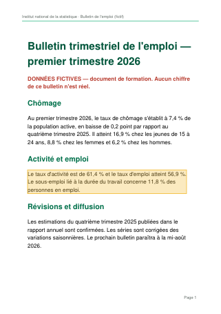

page 1

**[2]** Bulletin trimestriel de l'emploi T1 2026**Activité et emploi** · p. 1 · text · confiance 0.19  
“Le taux d'activité est de 61,4 % et le taux d'emploi atteint 56,9 %. Le sous-emploi lié à la durée du travail concerne 11,8 % des personnes en emploi.…”

**[3]** Bulletin trimestriel de l'emploi T1 2026**Révisions et diffusion** · p. 1 · text · confiance 0.00  
“Les estimations du quatrième trimestre 2025 publiées dans le rapport annuel sont confirmées. Les séries sont corrigées des variations saisonnières. Le prochain bulletin paraîtra à la mi-août 2026.…”

**[4]** Bulletin trimestriel de l'emploi T1 2026**début** · p. 1 · text · confiance 0.00  
“DONNÉES FICTIVES — document de formation. Aucun chiffre de ce bulletin n'est réel.…”

```python
if DOCUMENTS == ["exemple"]:
    BIB.afficher(BIB.repondre("Comment le taux de chômage a-t-il évolué entre le quatrième trimestre 2025 et le premier trimestre 2026 ?"))
    q = "Quel est le taux de chômage des jeunes ?"
    second = next((d for d in BIB.documents if "bulletin" in d.filename.lower()), None)
else:
    q = questions_suggerees()[0]
    second = BIB.documents[1] if len(BIB.documents) > 1 else None
BIB.afficher(BIB.repondre(q))
if second is not None:
    encadre(f"Plusieurs documents peuvent répondre, pour des périodes ou des champs différents. "
            f"Même question, limitée à « {_html.escape(second.short)} » :", "info")
    BIB.afficher(BIB.repondre(q, docs=[second.id]))
```

Parcours approfondi

B7 · Mémoire de conversation

Comprendre « et pour les hommes ? » grâce à la question précédente.

Une question de suivi n'a pas de sens à elle seule : « Et pour les hommes ? » ne contient aucun indicateur. Avant de rechercher, l'assistant **la réécrit en question autonome** :

| Méthode | Principe | Quand |
| --- | --- | --- |
| **Par le modèle** | Le modèle reçoit les derniers échanges et réécrit la question | Un modèle est disponible et `MEMOIRE_PAR_MODELE = True` |
| **Par règles** | La question précédente est reprise et la valeur qui change (région, sexe, trimestre, année, milieu, âge, indicateur) est **remplacée** | Sans modèle, ou en solution de repli |

La réécriture est **toujours affichée** (« 🧠 Compris comme : … ») pour que l'utilisateur puisse la vérifier.

> ⚠️ **La mémoire peut se tromper.** Si l'utilisateur change de sujet avec une question très courte, celle-ci peut être rattachée à tort à la précédente. D'où l'affichage systématique, et la possibilité de désactiver la mémoire dans les interfaces.

```python
if DOCUMENTS == ["exemple"]:
    conversation = ["Quel est le taux de chômage des femmes dans la région du Littoral ?",
                    "Et pour les hommes ?",
                    "Et dans la région du Nord ?",
                    "Quel est le taux de chômage au deuxième trimestre ?",
                    "Et au troisième trimestre ?"]
else:
    starters = questions_suggerees(4)
    conversation = [starters[0], "Et plus en détail ?", starters[1] if len(starters) > 1 else "Et ensuite ?"]
history, rows = [], []
for q in conversation:
    r = BIB.repondre(q, history=history)
    history.append(r)
    rows.append({"Question posée": q,
                 "Question recherchée": ("🧠 " if r["reformulee"] else "") + _html.escape(r["question_autonome"]),
                 "Méthode": r["methode_reformulation"] or "—",
                 "Réponse": _html.escape(r["reponse"][:110])})
tableau(pd.DataFrame(rows), title="Une conversation avec mémoire")
```

Une conversation avec mémoire

| Question posée | Question recherchée | Méthode | Réponse |
| --- | --- | --- | --- |
| Quel est le taux de chômage des femmes dans la région du Littoral ? | Quel est le taux de chômage des femmes dans la région du Littoral ? | — | Tableau 2 — Taux de chômage par région en 2025 (%): Littoral — Hommes: 8,1; Femmes: 11,2; Ensemble: 9,6. Centr |
| Et pour les hommes ? | 🧠 Quel est le taux de chômage des hommes dans la région du Littoral ? | règles | Tableau 2 — Taux de chômage par région en 2025 (%): Littoral — Hommes: 8,1; Femmes: 11,2; Ensemble: 9,6. Centr |
| Et dans la région du Nord ? | 🧠 Quel est le taux de chômage des hommes dans la région du Nord ? | règles | Tableau 2 — Taux de chômage par région en 2025 (%): Nord — Hommes: 5,9; Femmes: 8,0; Ensemble: 6,9. Sud — Homm |
| Quel est le taux de chômage au deuxième trimestre ? | Quel est le taux de chômage au deuxième trimestre ? | — | Tableau 1 — Indicateurs trimestriels du marché du travail en 2025 (%): Taux de chômage — T1: 8,3; T2: 7,8; T3: |
| Et au troisième trimestre ? | 🧠 Quel est le taux de chômage au troisième trimestre ? | règles | Tableau 1 — Indicateurs trimestriels du marché du travail en 2025 (%): Taux de chômage — T1: 8,3; T2: 7,8; T3: |

Parcours approfondi

B8 · Tester avant d'ouvrir l'assistant

Des questions dont les réponses sont connues, y compris des questions à refuser.

```python
if DOCUMENTS == ["exemple"]:
    JEU_TEST = [
        # famille, question, valeurs attendues (None = doit refuser), question précédente pour les relances
        ("Tableau", "Quel est le taux de chômage au deuxième trimestre ?", ["7,8"], None),
        ("Tableau", "Quelle est la population de la région du Centre ?", ["4 870 500"], None),
        ("Texte", "Quelle est la part de l'emploi informel dans l'emploi total ?", ["71,5"], None),
        ("Texte", "Quelle est la taille moyenne d'un ménage ?", ["5,1"], None),
        ("Reformulation", "Les chercheurs peuvent-ils accéder aux microdonnées ?", ["accès sécurisé"], None),
        ("Plusieurs documents", "Comment le taux de chômage a-t-il évolué entre le quatrième trimestre 2025 et le premier trimestre 2026 ?", ["7,4"], None),
        ("Plusieurs documents", "Quand paraîtra le prochain bulletin de l'emploi ?", ["août 2026"], None),
        ("Relance", "Et pour les hommes ?", ["8,1"], "Quel est le taux de chômage des femmes dans la région du Littoral ?"),
        ("Relance", "Et au troisième trimestre ?", ["7,7"], "Quel est le taux de chômage au deuxième trimestre ?"),
        ("Page scannée", "Quand est programmé le prochain recensement ?", ["2027"], None),
        ("Hors sujet", "Quel est le prix du maïs au kilogramme ?", None, None),
        ("Hors sujet", "Quel sera le taux de chômage en 2030 ?", None, None),
    ]
else:
    JEU_TEST = []   # 🧪 À compléter : ("Famille", "Question", ["valeur attendue"] ou None, question précédente ou None)
    # Jeu prêt à l'emploi pour les deux rapports ayant servi à régler ce notebook — décommentez si vous les chargez :
    #   Stratégie continentale de l'UA sur l'IA 2024 + guide BAD « Establishing a Data Innovation Lab » (2025)
    # JEU_TEST = [
    #     ("Chiffre", "Combien l'IA pourrait-elle apporter à l'économie mondiale d'ici 2030 selon PwC ?", ["15.7 trillion"], None),
    #     ("Date", "Quand la Stratégie continentale sur l'IA a-t-elle été adoptée ?", ["July 2024", "45th Ordinary Session"], None),
    #     ("Chiffre", "Combien d'organisations travaillent sur l'innovation en IA en Afrique ?", ["2,400"], None),
    #     ("Classement", "Quel pays est en tête de la préparation à l'IA en Afrique ?", ["Mauritius"], None),
    #     ("Sigle", "Que signifie DIL ?", ["Data Innovation Lab"], None),
    #     ("Structure", "Combien de dimensions compte le modèle de maturité de la BAD ?", ["12 dimensions"], None),
    #     ("Texte", "Qui doit réaliser le diagnostic DIL ?", ["NSO", "self-assessment"], None),
    #     ("Relance", "Et quels pays ont été évalués ?", ["Tunisia", "Senegal"], "Qui doit réaliser le diagnostic DIL ?"),
    #     ("Hors sujet", "Quel est le prix du maïs au kilogramme ?", None, None),
    #     ("Hors sujet", "Quel sera le taux de chômage en 2030 ?", None, None),
    # ]
    encadre("Vous utilisez vos propres PDF : remplissez <code>JEU_TEST</code> pour valider l'assistant.", "warning")

def _contains(text, values):
    norm = lambda s: sans_accents(_normaliser_nombres(s).lower())
    return any(norm(v) in norm(text) for v in values)

LIGNES_TEST = []
for family, question, expected, previous in JEU_TEST:
    hist = [BIB.repondre(previous)] if previous else []
    r = BIB.repondre(question, history=hist)
    ok = r["refus"] if expected is None else (not r["refus"] and _contains(r["reponse"], expected))
    LIGNES_TEST.append({"Famille": family, "Question": question + (f"<br><i>après : {previous}</i>" if previous else ""),
                      "Attendu": "refus" if expected is None else " ou ".join(expected),
                      "Réponse": _html.escape(r["reponse"][:130]),
                      "Chiffres": ("—" if not r["verification"] or not r["verification"]["nombres"]
                                  else "✅" if not r["verification"]["absents"] else "⚠️"),
                      "Résultat": "✅" if ok else "❌", "_ok": ok})
if LIGNES_TEST:
    TEST = pd.DataFrame(LIGNES_TEST)
    tableau(TEST.drop(columns="_ok"), title=f"🧪 Jeu de test : {TEST['_ok'].sum()} / {len(TEST)} correctes ({TEST['_ok'].mean():.0%})")
    if DOCUMENTS == ["exemple"] and not UTILISER_OCR:
        encadre("La question sur le prochain recensement porte sur une <b>page scannée</b> : sans OCR, le refus est "
                "le comportement attendu. Mettez <code>UTILISER_OCR = True</code> pour la rendre lisible.", "info")
```

🧪 Jeu de test : 11 / 12 correctes (92%)

| Famille | Question | Attendu | Réponse | Chiffres | Résultat |
| --- | --- | --- | --- | --- | --- |
| Tableau | Quel est le taux de chômage au deuxième trimestre ? | 7,8 | Tableau 1 — Indicateurs trimestriels du marché du travail en 2025 (%): Taux de chômage — T1: 8,3; T2: 7,8; T3: 7,7; T4: 7,6. Sous- | ✅ | ✅ |
| Tableau | Quelle est la population de la région du Centre ? | 4 870 500 | Tableau 1 — Population résidente par région en 2024: Centre — Population: 4 870 500; Part (%): 26,4; Part urbaine (%): 44,1. Nord | ✅ | ✅ |
| Texte | Quelle est la part de l'emploi informel dans l'emploi total ? | 71,5 | • La part de l'emploi informel dans l'emploi total est estimée à 71,5 %. • Le chômage des jeunes de 15 à 24 ans reste élevé, à 1 | ✅ | ✅ |
| Texte | Quelle est la taille moyenne d'un ménage ? | 5,1 | La taille moyenne d'un ménage est de 5,1 personnes, contre 5,4 en 2013. Un ménage sur quatre est dirigé par une femme. [1] | ✅ | ✅ |
| Reformulation | Les chercheurs peuvent-ils accéder aux microdonnées ? | accès sécurisé | Les fichiers de microdonnées anonymisés sont accessibles aux chercheurs dans le centre d'accès sécurisé aux données de l'Institut, | — | ✅ |
| Plusieurs documents | Comment le taux de chômage a-t-il évolué entre le quatrième trimestre 2025 et le premier trimestre 2026 ? | 7,4 | Au premier trimestre 2026, le taux de chômage s'établit à 7,4 % de la population active, en baisse de 0,2 point par rapport au qua | ✅ | ✅ |
| Plusieurs documents | Quand paraîtra le prochain bulletin de l'emploi ? | août 2026 | Le prochain bulletin paraîtra à la mi-août 2026. [1] | ✅ | ✅ |
| Relance | Et pour les hommes ? *après : Quel est le taux de chômage des femmes dans la région du Littoral ?* | 8,1 | Tableau 2 — Taux de chômage par région en 2025 (%): Littoral — Hommes: 8,1; Femmes: 11,2; Ensemble: 9,6. Centre — Hommes: 6,4; Fem | ✅ | ✅ |
| Relance | Et au troisième trimestre ? *après : Quel est le taux de chômage au deuxième trimestre ?* | 7,7 | Tableau 1 — Indicateurs trimestriels du marché du travail en 2025 (%): Taux de chômage — T1: 8,3; T2: 7,8; T3: 7,7; T4: 7,6. Sous- | ✅ | ✅ |
| Page scannée | Quand est programmé le prochain recensement ? | 2027 | Au 15 mars 2024, date de référence du recensement, la population résidente du pays s'élève à 18 452 300 personnes, contre 14 208 9 | ✅ | ❌ |
| Hors sujet | Quel est le prix du maïs au kilogramme ? | refus | Information non disponible dans les documents. | — | ✅ |
| Hors sujet | Quel sera le taux de chômage en 2030 ? | refus | Information non disponible dans les documents. | — | ✅ |

Parcours approfondi

B9 · Signaler les doutes et vérifier les chiffres

Trois contrôles automatiques affichés avec chaque réponse.

Même avec des garde-fous, une réponse peut n'être que **partiellement** fondée. Trois contrôles sont donc affichés sur chaque fiche de réponse :

| Contrôle | Principe | Ce qu'il détecte |
| --- | --- | --- |
| **Chiffres vérifiés** | Chaque nombre de la réponse doit figurer dans une source fournie | Un modèle qui arrondit, confond ou **invente** un chiffre |
| **Termes non trouvés** | Les mots de la question absents du passage principal sont listés | Une réponse portant sur **un autre indicateur** que celui demandé |
| **Meilleure réponse ailleurs** | Si le filtre exclut un document bien plus pertinent, c'est signalé | Un filtre de documents trop restrictif |

> 💡 **Point clé.** Ces contrôles ne remplacent pas la relecture : ils **orientent** l'attention du lecteur vers les réponses à vérifier en priorité.

```python
# 1. Contrôle des chiffres : une réponse exacte et une réponse « inventée », avec les mêmes sources.
r = BIB.repondre("Quel est le taux de chômage au deuxième trimestre ?")
tableau(pd.DataFrame([
    {"Réponse testée": "Le taux de chômage s'établit à 7,8 % au deuxième trimestre [1].",
     "Contrôle": str(verifier_chiffres("Le taux de chômage s'établit à 7,8 % au deuxième trimestre [1].", r["passages"]))},
    {"Réponse testée": "Le taux de chômage s'établit à 7,3 % au deuxième trimestre [1].",
     "Contrôle": str(verifier_chiffres("Le taux de chômage s'établit à 7,3 % au deuxième trimestre [1].", r["passages"]))},
]), title="Contrôle des chiffres", note="7,3 ne figure dans aucune source : il est signalé.")

# 2. Termes non trouvés et 3. meilleure réponse ailleurs : une question de population, filtrée sur le rapport annuel.
report = next((d for d in BIB.documents if "rapport" in d.filename.lower()), BIB.documents[0])
BIB.afficher(BIB.repondre("Quelle est la population de la région du Nord ?", docs=[report.id]))
```

Contrôle des chiffres

| Réponse testée | Contrôle |
| --- | --- |
| Le taux de chômage s'établit à 7,8 % au deuxième trimestre [1]. | {'nombres': 1, 'absents': []} |
| Le taux de chômage s'établit à 7,3 % au deuxième trimestre [1]. | {'nombres': 1, 'absents': ['7.3']} |

7,3 ne figure dans aucune source : il est signalé.

❓ Quelle est la population de la région du Nord ?

RÉPONSEconfiance 0.81extractivechiffres vérifiés 8/811:41:09 · 0.12 s

⚠️ Introuvable dans la source principale : **population** — vérifiez que la réponse porte bien sur votre question.

💡 Une réponse plus pertinente figure probablement dans « **Recensement de la population 2024** », exclu par le filtre.

Tableau 2 — Taux de chômage par région en 2025 (%): Nord — Hommes: 5,9; Femmes: 8,0; Ensemble: 6,9. Sud — Hommes: 6,2; Femmes: 8,7; Ensemble: 7,4. <sup>1</sup>

**Sources (4)**

page 3

**[1]** Rapport annuel sur le marché du travail…**5. Chômage** · p. 3 · table · confiance 0.81  
“Tableau 2 — Taux de chômage par région en 2025 (%) Littoral — Hommes: 8,1; Femmes: 11,2; Ensemble: 9,6. Centre — Hommes: 6,4; Femmes: 8,9; Ensemble: 7,6. Nord — Hommes: 5,9; Femmes: 8,0; Ensemble: 6,9. Sud — Hommes: 6,2;…”

page 2

**[2]** Rapport annuel sur le marché du travail…**5. Chômage** · p. 2 · text · confiance 0.35  
“Le chômage touche davantage les femmes (9,3 %) que les hommes (6,7 %). Il est plus élevé en milieu urbain (10,4 %) qu'en milieu rural (5,2 %). Le tableau 2 détaille le taux de chômage par région.…”

**[3]** Rapport annuel sur le marché du travail…**7. Méthodologie** · p. 3 · text · confiance 0.35  
“L'enquête repose sur un tirage aléatoire à deux degrés. Six cents zones de dénombrement sont sélectionnées avec une probabilité proportionnelle à leur taille, puis vingt logements sont tirés dans chaque zone, soit 12 000…”

**[4]** Rapport annuel sur le marché du travail…**3. Population en âge de travailler** · p. 1, 2 · text · confiance 0.19  
“En 2025, la population en âge de travailler compte 11,2 millions de personnes. Les femmes en représentent 50,8 %. La population active est estimée à 6,85 millions de personnes, dont 6,31 millions d'actifs occupés et 0,54…”

Regardez la fiche ci-dessus. Restreint au rapport annuel, le meilleur passage est un tableau des **taux de chômage** par région : la question n'est que partiellement couverte. Selon le score de confiance, l'assistant soit **refuse**, soit répond avec le taux de chômage du Nord en signalant que « population » **n'a pas été trouvé** dans la source. Dans les deux cas, la fiche souligne que le **recensement**, exclu par le filtre, contient probablement la bonne réponse.

PARTIE C

💬 Les interfaces

Dialoguez avec vos documents, dans le notebook ou dans un navigateur.

|  | **C1 · Dans le notebook** | **C2 · Application web (Gradio)** |
| --- | --- | --- |
| Où | Sous la cellule | Onglet du navigateur, ou **lien public** |
| Pour qui | Vous | Vous **et vos collègues**, sans écrire de code |
| Ajouter des PDF | Réglage `DOCUMENTS` | **Glisser-déposer** dans la page |
| Filtre de documents, mémoire, seuil, garde-fous | ✅ | ✅ |
| Vignettes de page avec surlignage | ✅ | ✅ |
| Contrôles (chiffres, termes, filtre) | ✅ | ✅ |
| Avis 👍 / 👎 enregistrés | ✅ | ✅ |

> 💡 **Les avis des utilisateurs** sont enregistrés dans `avis_utilisateurs.csv` avec la question, la réponse et ses sources. Les réponses marquées « à revoir » sont le meilleur matériau pour **enrichir le glossaire et le jeu de test**.

Interfaces

C1 · L'interface dans le notebook

Questions suggérées, filtre de documents, mémoire, réglages et avis.

```python
import ipywidgets as widgets

HISTORIQUE = []
SUGGESTIONS = questions_suggerees(5)

def _entete():
    model_label = f"{LLM.name} · {LLM.model}" if LLM.available else "mode extractif"
    return (f'{_CSS}<div class="rg" style="background:linear-gradient(120deg,{C["forest"]} 0%,{C["green"]} 100%);'
            f'border-radius:14px;padding:14px 20px;color:#fff;"><div style="color:{C["gold"]};font-size:11px;'
            f'font-weight:700;letter-spacing:2.5px;">ASSISTANT DOCUMENTAIRE</div>'
            f'<div style="font-size:20px;font-weight:800;margin:2px 0;">💬 {len(BIB.documents)} document(s) · '
            f'{len(BIB.passages)} passages</div><div style="font-size:12.5px;color:#E6F6EE;">modèle : '
            f'{_html.escape(model_label)} · recherche : {_html.escape(BIB.semantic.name)}</div></div>')

def _fil():
    if not HISTORIQUE:
        return (f'{_CSS}<div class="rg rg-card" style="text-align:center;color:{C["slate"]};padding:26px;">'
                'Posez une question, ou cliquez sur une suggestion.</div>')
    bubbles = "".join(
        f'<div style="display:flex;justify-content:flex-end;margin:12px 0 6px 0;"><div style="background:{C["dark_green"]};'
        f'color:#fff;border-radius:14px 14px 2px 14px;padding:8px 14px;max-width:80%;font-size:14px;">'
        f'{_html.escape(r["question"])}</div></div><div style="display:flex;gap:8px;align-items:flex-start;">'
        f'<div style="font-size:22px;">🤖</div><div style="flex:1;">{BIB.carte_html(r, ui_vignettes.value)}</div></div>'
        for r in reversed(HISTORIQUE))
    return (f'{_CSS}<div class="rg" style="max-height:720px;overflow-y:auto;padding:4px 6px;border:1px solid '
            f'{C["sage"]};border-radius:12px;background:{C["mist"]};">{bubbles}</div>')

ui_question = widgets.Text(placeholder="Posez une question sur les documents…", layout=widgets.Layout(flex="1", width="auto"))
ui_envoyer = widgets.Button(description="Envoyer", button_style="success", icon="paper-plane", layout=widgets.Layout(width="120px"))
ui_etat = widgets.HTML("")
ui_docs = [widgets.Checkbox(value=True, description=d.short, indent=False, layout=widgets.Layout(width="auto", margin="0 14px 0 0"))
           for d in BIB.documents]
ui_k = widgets.IntSlider(value=K_RESULTATS, min=1, max=8, description="Passages", continuous_update=False)
ui_seuil = widgets.FloatSlider(value=float(BIB.threshold), min=0.0, max=1.0, step=0.01, description="Seuil",
                                   continuous_update=False, readout_format=".2f")
ui_garde_fous = widgets.Checkbox(value=True, description="Garde-fous actifs", indent=False)
ui_memoire = widgets.Checkbox(value=True, description="Mémoire de conversation", indent=False)
ui_vignettes = widgets.Checkbox(value=True, description="Afficher les pages", indent=False)
ui_effacer = widgets.Button(description="Nouvelle conversation", icon="refresh", layout=widgets.Layout(width="200px"))
ui_exporter = widgets.Button(description="Exporter", icon="download", layout=widgets.Layout(width="120px"))
ui_utile = widgets.Button(description="Utile", icon="thumbs-up", layout=widgets.Layout(width="100px"))
ui_a_revoir = widgets.Button(description="À revoir", icon="thumbs-down", layout=widgets.Layout(width="130px"))
ui_commentaire = widgets.Text(placeholder="Commentaire facultatif sur la dernière réponse…", layout=widgets.Layout(flex="1", width="auto"))
ui_fil = widgets.HTML(_fil())

def donner_avis(useful):
    if not HISTORIQUE:
        ui_etat.value = "Posez d'abord une question."
        return
    enregistrer_avis(HISTORIQUE[-1], useful, ui_commentaire.value.strip(), "notebook")
    ui_commentaire.value = ""
    ui_etat.value = (f'<span style="color:{C["dark_green"]};">Merci ! Avis enregistré '
                       f'({len(AVIS)} au total, fichier avis_utilisateurs.csv).</span>')

def envoyer(_=None, question=None):
    q = (question or ui_question.value).strip()
    if not q:
        return
    docs = [d.id for d, c in zip(BIB.documents, ui_docs) if c.value]
    if not docs:
        ui_etat.value = f'<span style="color:{C["brick"]};">Cochez au moins un document.</span>'
        return
    ui_question.value = ""
    ui_envoyer.disabled = True
    ui_etat.value = f'<span style="color:{C["teal"]};">⏳ Recherche dans {len(docs)} document(s)…</span>'
    try:
        r = BIB.repondre(q, history=HISTORIQUE if ui_memoire.value else None, docs=docs, k=ui_k.value,
                       threshold=ui_seuil.value, guardrails=ui_garde_fous.value, memory=ui_memoire.value)
        HISTORIQUE.append(r)
        ui_etat.value = (f'<span style="color:{C["slate"]};font-size:12px;">{len(HISTORIQUE)} échange(s) · '
                           f'dernière réponse en {r["duree_s"]} s' + (f' · {LLM.calls} appel(s) au modèle' if LLM.available else "") + "</span>")
    except Exception as error:
        ui_etat.value = f'<span style="color:{C["brick"]};">⛔ {_html.escape(str(error)[:200])}</span>'
    finally:
        ui_envoyer.disabled = False
        ui_fil.value = _fil()

def nouvelle_conversation(_=None):
    HISTORIQUE.clear()
    ui_fil.value = _fil()
    ui_etat.value = ""

def _serialiser(r):
    return {"question": r["question"], "question_autonome": r["question_autonome"], "reponse": r["reponse"],
            "refus": r["refus"], "confiance": round(r["confiance"], 3), "motif": r["motif"], "mode": r["mode"],
            "garde_fous": r["garde_fous"], "verification": r["verification"], "heure": r["heure"],
            "sources": [{"document": p.doc, "section": p.section, "pages": p.pages, "type_question": p.kind,
                         "confiance": round(s, 3), "text": p.text} for p, s in r["passages"]]}

def exporter(_=None):
    if not HISTORIQUE:
        ui_etat.value = "Rien à exporter pour l'instant."
        return
    stamp = time.strftime("%Y%m%d_%H%M%S")
    (DOSSIER_SORTIE / f"conversation_{stamp}.json").write_text(
        json.dumps({"documents": [d.title for d in BIB.documents], "turns": [_serialiser(r) for r in HISTORIQUE]},
                   ensure_ascii=False, indent=2), encoding="utf-8")
    html_path = DOSSIER_SORTIE / f"conversation_{stamp}.html"
    html_path.write_text(f'<html><head><meta charset="utf-8"><title>Conversation</title></head>'
                         f'<body style="max-width:900px;margin:auto;">{_entete()}{_fil()}</body></html>', encoding="utf-8")
    ui_etat.value = f"✅ Conversation exportée : <code>{html_path.name}</code> (et sa version JSON)"
    if ENV["name"] == "colab":
        from google.colab import files
        files.download(str(html_path))

buttons = []
for s in SUGGESTIONS:
    b = widgets.Button(description=(s[:44] + "…") if len(s) > 45 else s, tooltip=s,
                       layout=widgets.Layout(width="auto", margin="2px 4px 2px 0"))
    b.on_click(lambda _, s=s: envoyer(question=s))
    buttons.append(b)
ui_envoyer.on_click(envoyer)
ui_utile.on_click(lambda _: donner_avis(True))
ui_a_revoir.on_click(lambda _: donner_avis(False))
ui_effacer.on_click(nouvelle_conversation)
ui_exporter.on_click(exporter)
ui_vignettes.observe(lambda _: setattr(ui_fil, "value", _fil()), names="value")
try:
    import warnings
    with warnings.catch_warnings():
        warnings.simplefilter("ignore")
        ui_question.on_submit(envoyer)
except Exception:
    pass

panneau_reglages = widgets.Accordion(children=[widgets.VBox([
    ui_k, ui_seuil, widgets.HBox([ui_garde_fous, ui_memoire, ui_vignettes])])])
panneau_reglages.set_title(0, "⚙️ Réglages")
panneau_reglages.selected_index = None

INTERFACE = widgets.VBox([
    widgets.HTML(_entete()),
    widgets.HTML('<div style="font-size:12.5px;margin:10px 0 2px 0;"><b>Documents interrogés</b></div>'),
    widgets.HBox(ui_docs, layout=widgets.Layout(flex_flow="row wrap")),
    widgets.HTML('<div style="font-size:12.5px;margin:8px 0 2px 0;"><b>Suggestions</b></div>'),
    widgets.HBox(buttons, layout=widgets.Layout(flex_flow="row wrap")),
    widgets.HBox([ui_question, ui_envoyer], layout=widgets.Layout(margin="8px 0 2px 0")),
    ui_etat, panneau_reglages,
    widgets.HBox([widgets.HTML('<span style="font-size:12.5px;margin-right:6px;"><b>Dernière réponse :</b></span>'),
                  ui_utile, ui_a_revoir, ui_commentaire]),
    widgets.HBox([ui_effacer, ui_exporter]), ui_fil,
], layout=widgets.Layout(width="100%", max_width="980px"))
display(INTERFACE)
```

```
VBox(children=(HTML(value='<style>\n.rg {font-family:\'Segoe UI\',Calibri,system-ui,sans-serif;color:#231F20;}…
```

> 💡 **Les widgets ne s'affichent pas ?** Certains éditeurs locaux ne les prennent pas en charge. Utilisez la fonction `demander("…")` de l'étape A3, ou l'application web ci-dessous.

Interfaces

C2 · L'application web partageable

Une interface Gradio avec import de PDF et lien public.

**Gradio** est une bibliothèque Python libre et gratuite qui transforme des fonctions Python en page web interactive — sans HTML ni JavaScript. L'application porte toutes les fonctionnalités de l'assistant sur une page web :

- **glisser-déposer** de nouveaux PDF, indexés à la volée ;
- **filtrer** les documents interrogés ;
- **conversation avec mémoire**, avec la réécriture affichée ;
- **sources** avec vignettes de page surlignées et contrôles automatiques ;
- **👍 / 👎** sous chaque réponse ;
- **réglages** : nombre de passages, seuil, garde-fous, mémoire.

Sur **Colab** et **Kaggle**, Gradio crée un **lien public temporaire** (`https://….gradio.live`), valable tant que la session tourne et pour une durée limitée. **En local**, l'application s'ouvre à l'adresse `http://127.0.0.1:7860`. L'application tourne **dans votre session de notebook** : si la session s'arrête, la page cesse de fonctionner.

> ⚠️ **Confidentialité.** Toute personne disposant du lien public peut interroger vos documents et téléverser des fichiers. **Définissez `MOT_DE_PASSE_WEB`** avant de partager un lien, et n'utilisez pas de lien public pour des documents non publiés.

> ⚠️ **Application partagée.** Tous les utilisateurs d'un même lien partagent la même bibliothèque : un PDF téléversé par l'un devient interrogeable par tous. Chaque utilisateur conserve sa propre conversation.

```python
def _installer_gradio():
    try:
        import gradio as gr
        if int(gr.__version__.split(".")[0]) >= 5:
            return gr
        print(f"Gradio {gr.__version__} est trop ancien : mise à jour…")
    except ImportError:
        print("Installation de Gradio (environ une minute)…")
    subprocess.run([sys.executable, "-m", "pip", "install", "-q", "-U", "gradio>=5"], check=False)
    importlib.invalidate_caches()
    import gradio as gr
    if int(gr.__version__.split(".")[0]) < 5:
        raise RuntimeError("Redémarrez la session (Exécution → Redémarrer la session), puis relancez le notebook.")
    return gr

def _libelles_docs():
    return [f"{d.id} · {d.short}" for d in BIB.documents]

def _resume_bibliotheque():
    return (f"**{len(BIB.documents)} document(s)** · {len(BIB.passages)} passages · seuil {BIB.threshold:.2f} · "
            + (f"modèle **{LLM.name}**" if LLM.available else "mode extractif"))

def creer_application():
    gr = _installer_gradio()
    import inspect
    theme = gr.themes.Soft(primary_hue="emerald", secondary_hue="amber", neutral_hue="slate")
    css = ".gradio-container {max-width: 1250px !important} footer {display: none !important}"
    blocks_args = {"title": "Assistant documentaire RAG"}
    blocks_params = inspect.signature(gr.Blocks.__init__).parameters
    if "theme" in blocks_params:
        blocks_args.update(theme=theme, css=css)
    chat_params = inspect.signature(gr.Chatbot.__init__).parameters
    chat_args = {"height": 470, "label": "Conversation"}
    if "type" in chat_params:
        chat_args["type"] = "messages"
    if "feedback_options" in chat_params:
        chat_args["feedback_options"] = ["Utile", "À revoir"]

    def reponse_web(question, messages, memory_state, docs, k, threshold, guardrails, memory):
        messages = list(messages or [])
        if not question or not question.strip():
            return "", messages, memory_state, gr.update()
        ids = [int(x.split(" · ")[0]) for x in (docs or [])]
        if not ids:
            messages.append({"role": "assistant", "content": "Cochez au moins un document."})
            return "", messages, memory_state, gr.update()
        hist = [{"question_autonome": h["question_autonome"], "reponse": h["reponse"]} for h in (memory_state or [])]
        r = BIB.repondre(question.strip(), history=hist if memory else None, docs=ids, k=int(k),
                       threshold=float(threshold), guardrails=bool(guardrails), memory=bool(memory))
        text = r["reponse"]
        if r["reformulee"]:
            text = f"_🧠 Comprise comme : {r['question_autonome']}_\n\n" + text
        if r["motif"]:
            text += f"\n\n_Motif : {r['motif']}_"
        if not r["refus"]:
            text += "\n\n" + "\n".join(f"**[{i}]** {p.citation}" for i, (p, _) in enumerate(r["passages"], 1))
        messages += [{"role": "user", "content": question.strip()}, {"role": "assistant", "content": text}]
        memory_state = (memory_state or []) + [{"question": r["question"], "question_autonome": r["question_autonome"],
                                                "reponse": r["reponse"], "citations": r["citations"]}]
        return "", messages, memory_state, f"{_CSS}{BIB.carte_html(r)}"

    def noter(data: gr.LikeData, memory_state):
        index = data.index[0] if isinstance(data.index, (list, tuple)) else data.index
        turns = memory_state or []
        position = int(index) // 2
        if not turns or position >= len(turns):
            return "Avis non enregistré : échange introuvable."
        useful = data.liked if isinstance(data.liked, bool) else str(data.liked).lower() in ("true", "like")
        enregistrer_avis(turns[position], useful, channel="web")
        return f"Merci ! Avis enregistré ({len(AVIS)} au total)."

    def ajouter_pdfs(files, docs):
        if not files:
            return gr.update(), _resume_bibliotheque(), ""
        paths = [f if isinstance(f, str) else getattr(f, "name", str(f)) for f in files]
        added, errors = BIB.charger(paths)
        BIB.indexer()
        choices = _libelles_docs()
        ticked = list(docs or []) + [f"{d.id} · {d.short}" for d in added]
        message = f"✅ {len(added)} document(s) ajouté(s)." + "".join(f"\n⚠️ {n} : {e}" for n, e in errors)
        return gr.update(choices=choices, value=[c for c in choices if c in ticked]), _resume_bibliotheque(), message

    with gr.Blocks(**blocks_args) as app:
        gr.HTML('<div style="background:linear-gradient(120deg,#00553A 0%,#00A86A 100%);border-radius:14px;'
                'padding:16px 22px;color:#fff;font-family:\'Segoe UI\',Calibri,sans-serif;">'
                '<div style="color:#F5C242;font-size:11px;font-weight:700;letter-spacing:2.5px;">ASSISTANT DOCUMENTAIRE · RAG</div>'
                '<div style="font-size:24px;font-weight:800;">💬 Posez vos questions sur vos rapports PDF</div>'
                '<div style="font-size:13px;color:#E6F6EE;">Des réponses sourcées, les pages surlignées, et un refus '
                'quand l\'information n\'est pas dans les documents.</div></div>')
        memory_state = gr.State([])
        with gr.Row():
            with gr.Column(scale=1, min_width=300):
                summary = gr.Markdown(_resume_bibliotheque())
                docs = gr.CheckboxGroup(choices=_libelles_docs(), value=_libelles_docs(), label="Documents interrogés")
                upload = gr.File(label="Ajouter des PDF", file_count="multiple", file_types=[".pdf"])
                add_button = gr.Button("📥 Ajouter et indexer")
                add_message = gr.Markdown("")
                with gr.Accordion("⚙️ Réglages", open=False):
                    k = gr.Slider(1, 8, value=K_RESULTATS, step=1, label="Passages fournis")
                    threshold = gr.Slider(0.0, 1.0, value=float(BIB.threshold), step=0.01, label="Seuil de confiance")
                    guardrails = gr.Checkbox(value=True, label="Garde-fous actifs")
                    memory = gr.Checkbox(value=True, label="Mémoire de conversation")
            with gr.Column(scale=2):
                chat = gr.Chatbot(**chat_args)
                with gr.Row():
                    question = gr.Textbox(placeholder="Posez une question sur les documents…", show_label=False,
                                          scale=5, autofocus=True)
                    send_button = gr.Button("Envoyer", variant="primary", scale=1)
                gr.Examples(examples=[[s] for s in SUGGESTIONS], inputs=[question], label="Suggestions")
                with gr.Row():
                    new_chat = gr.Button("🔄 Nouvelle conversation", size="sm")
                    feedback_message = gr.Markdown("_Utilisez 👍 / 👎 sous chaque réponse pour donner votre avis._")
                with gr.Accordion("📄 Sources de la dernière réponse", open=True):
                    sources = gr.HTML("<i>Les sources apparaîtront ici.</i>")
        inputs = [question, chat, memory_state, docs, k, threshold, guardrails, memory]
        outputs = [question, chat, memory_state, sources]
        send_button.click(reponse_web, inputs, outputs)
        question.submit(reponse_web, inputs, outputs)
        new_chat.click(lambda: ([], [], "<i>Les sources apparaîtront ici.</i>"), None, [chat, memory_state, sources])
        add_button.click(ajouter_pdfs, [upload, docs], [docs, summary, add_message])
        if hasattr(chat, "like"):
            chat.like(noter, [memory_state], [feedback_message])
    app._launch_args = {} if "theme" in blocks_params else {"theme": theme, "css": css}
    return app

def lancer_application(app):
    import inspect
    auth = (UTILISATEUR_WEB, MOT_DE_PASSE_WEB) if MOT_DE_PASSE_WEB else None
    options = dict(share=PARTAGER_LIEN, auth=auth, prevent_thread_lock=True, quiet=True, show_error=True,
                   inbrowser=(ENV["name"] == "local"), inline=(ENV["name"] == "colab"), **app._launch_args)
    params = inspect.signature(app.launch).parameters
    options = {k: v for k, v in options.items() if k in params}
    try:
        app.launch(**options)
    except Exception as error:
        if options.get("share"):
            print(f"⚠️ Lien public indisponible ({type(error).__name__}) : lancement en local.")
            options["share"] = False
            app.launch(**options)
        else:
            raise
    public_url = getattr(app, "share_url", None)
    local_url = getattr(app, "local_url", None) or "http://127.0.0.1:7860"
    lines = [f'<div style="font-size:14px;margin:4px 0;">🔗 <b>Lien public :</b> <a href="{public_url}" target="_blank">{public_url}</a></div>'
             if public_url else "",
             f'<div style="font-size:14px;margin:4px 0;">💻 <b>Adresse locale :</b> <code>{local_url}</code></div>',
             f'<div style="font-size:13px;margin:4px 0;">🔒 Accès : ' + (f'identifiant <code>{UTILISATEUR_WEB}</code> et mot de passe défini'
             if auth else f'<span style="color:{C["brick"]};"><b>aucun mot de passe</b></span>') + '</div>']
    display(HTML(f'{_CSS}<div class="rg rg-card" style="border-left:6px solid {C["green"]};">'
                 f'<div class="rg-title">🌐 Application web en service</div>{"".join(lines)}'
                 f'<div class="rg-note">Pour l\'arrêter : exécutez <code>APP.close()</code>. Elle s\'arrête aussi à la fin de la session.</div></div>'))
    if public_url and not auth:
        encadre("Le lien est public et <b>sans mot de passe</b> : définissez <code>MOT_DE_PASSE_WEB</code> avant de le partager.", "warning")

if LANCER_INTERFACE_WEB:
    APP = creer_application()
    lancer_application(APP)
else:
    encadre("Application web non lancée (<code>LANCER_INTERFACE_WEB = False</code>).", "info")
```

🌐 Application web en service

💻 **Adresse locale :** `http://127.0.0.1:7862/`

🔒 Accès : **aucun mot de passe**

Pour l'arrêter : exécutez `APP.close()`. Elle s'arrête aussi à la fin de la session.

```python
# Arrêter l'application web (décommentez la ligne suivante).
# APP.close()
```

PARTIE D

📦 Les livrables

Réglages, passages, tests, conversations et avis.

```python
config = {
    "documents": [{"titre": d.title, "fichier": d.filename, "pages": d.pages, "pages_scannees": d.scanned_pages,
                   "elements": dict(Counter(e.type for e in d.elements))} for d in BIB.documents],
    "langue_documents": LANGUE, "passages": len(BIB.passages), "ocr": UTILISER_OCR, "taille_max": TAILLE_MAX,
    "strategie_decoupage": STRATEGIE_DECOUPAGE, "niveau_decoupage": NIVEAUX_DECOUPAGE[STRATEGIE_DECOUPAGE][0],
    "reclassement": BIB.reranker.mode, "niveau_reclassement": BIB.reranker.name, "unites_recherche": len(BIB.units),
    "vocabulaire": len(FORMES_VOCABULAIRE),
    "sigles_appris": len(SIGLES), "cache": bool(UTILISER_CACHE), "lignes_sommaire_ecartees":
        sum(d.info.get("lignes de sommaire écartées", 0) for d in BIB.documents),
    "k_resultats": K_RESULTATS, "recherche_semantique": BIB.semantic.name, "seuil": BIB.threshold,
    "seuil_calibre": BIB.calibrated_threshold, "fournisseur": LLM.name, "modele": LLM.model,
    "appels_modele": LLM.calls, "environnement": ENV["name"], "date": time.strftime("%Y-%m-%d %H:%M"),
}
(DOSSIER_SORTIE / "configuration.json").write_text(json.dumps(config, ensure_ascii=False, indent=2), encoding="utf-8")
pd.DataFrame([{"id": p.id, "document": p.doc, "section": p.section, "pages": ",".join(map(str, p.pages)),
               "nature": p.kind, "texte": p.text} for p in BIB.passages]).to_csv(
    DOSSIER_SORTIE / "passages.csv", index=False, encoding="utf-8-sig")
BIB.calibration.to_csv(DOSSIER_SORTIE / "calibration.csv", index=False, encoding="utf-8-sig")
if LIGNES_TEST:
    TEST.drop(columns="_ok").to_csv(DOSSIER_SORTIE / "jeu_de_test.csv", index=False, encoding="utf-8-sig")
if HISTORIQUE:
    exporter()
if AVIS:
    fb = pd.DataFrame(AVIS)
    tableau(fb[["horodatage", "canal", "utile", "question", "commentaire"]].assign(
                   avis=lambda d: d["utile"].map({True: "👍", False: "👎"})),
               title=f"🗳️ {len(fb)} avis · {fb['utile'].mean():.0%} jugés utiles",
               note="Les réponses marquées « à revoir » devraient rejoindre le jeu de test, avec la bonne réponse.")

archive = shutil.make_archive(str(ENV["root"] / "livrables_rag"), "zip", DOSSIER_SORTIE)
files_list = sorted(p.name for p in DOSSIER_SORTIE.iterdir())
tableau(pd.DataFrame({"Fichier": ["livrables_rag.zip"] + files_list}),
           title=f"📦 {len(files_list)} livrable(s)",
           note="configuration.json : les réglages · passages.csv : le texte indexé · calibration.csv et "
                "jeu_de_test.csv : les preuves de validation · conversation_* : les échanges exportés · "
                "avis_utilisateurs.csv : les avis 👍 / 👎.")
if ENV["name"] == "colab":
    if COPIER_SUR_DRIVE:
        from google.colab import drive
        drive.mount("/content/drive")
        target = Path("/content/drive/MyDrive/livrables_rag")
        target.mkdir(parents=True, exist_ok=True)
        shutil.copy(archive, target / f"livrables_rag_{time.strftime('%Y%m%d_%H%M')}.zip")
        encadre(f"Archive copiée dans Google Drive, dans <code>{target}</code>.", "success")
    if TELECHARGER_LIVRABLES:
        from google.colab import files
        files.download(archive)
        encadre("Téléchargement de l'archive lancé : les fichiers d'une session Colab sont supprimés à sa fermeture.", "warning")
elif ENV["name"] == "kaggle":
    encadre("Les livrables sont dans <code>/kaggle/working</code> : cliquez sur <b>Save Version</b> pour les conserver.", "info")
else:
    encadre(f"Archive disponible sur votre disque : <code>{archive}</code>.", "success")
```

📦 6 livrable(s)

| Fichier |
| --- |
| livrables_rag.zip |
| calibration.csv |
| calibration_seuil.png |
| configuration.json |
| diagnostic_pages.png |
| jeu_de_test.csv |
| passages.csv |

configuration.json : les réglages · passages.csv : le texte indexé · calibration.csv et jeu_de_test.csv : les preuves de validation · conversation_* : les échanges exportés · avis_utilisateurs.csv : les avis 👍 / 👎.

✅ Archive disponible sur votre disque : `C:\Users\ASUS\Docs\livrables_rag.zip`.

PARTIE E

Aller plus loin

Limites, améliorations, points de contrôle et dépannage.